# HW2-yz3079

## 1. Preliminaries

### 1.1. Data Construction

$X$ is the "design matrix" with M*D(150*75)

w_true is the true weight vector $w_{true} \in\mathbf R^{d\times 1}$

y is the response with M*1

```python
import numpy as np
from scipy.optimize import minimize
import matplotlib.pyplot as plt
import timeit
%matplotlib inline
```

```python
m = 150
d = 75
```

```python
np.random.seed(1738)
### Design Matrix ###
X = np.random.rand(m,d)
### Weight Vector ###
w_true = np.zeros(d)
w_true[:10] = (np.random.choice(2,10)-0.5)*2
### Response ###
sigma = 0.1
mu = 0
epsilon = sigma*np.random.randn(m) + mu
y = np.dot(X, w_true)+epsilon
```

```python
X_train = X[:80,:]
X_validation = X[80:100,:]
X_test = X[-50:150,:]
```

```python
y_train = y[:80]
y_validation = y[80:100]
y_test = y[-50:150]
```

### 1.2. Ridge Regression

Run ridge regression on this dataset. Choose the $\lambda$ that minimizes the square loss on the validation set.

```python
def ridge(X, y, Lambda):
    (N, D) = X.shape
    def ridge_obj(theta):
        return ((np.linalg.norm(np.dot(X, theta) - y))**2) / (2 * N) +\
            Lambda * (np.linalg.norm(theta))**2
    return ridge_obj

def compute_loss(X, y, theta):
    (N, D) = X.shape
    return ((np.linalg.norm(np.dot(X, theta) - y))**2) / (2 * N)

def ridge_regression(Lambda=0):
    """
    Args:
        lambda - if not given loop through differen lambdas and find the best
    Returns:
        theta_opt - the optimization of parameter vector, 1D numpy array of size (num_features)
        lambda_opt - the history optimization of parameter, 1D numpy array of size (num_lambdas)
        loss_opt - the history of regularized loss value, 1D numpy array of size (num_lambdas)
    """
    (N, D) = X.shape
    w = np.random.rand(D, 1)
    Lambda_history = []
    loss_history = []
    t = 0
    loss_min=lambda_min=w_min=np.nan
    if (Lambda==0):
        for i in range(-9, 1):
            Lambda = 10**i
            Lambda_history.append(Lambda)
            w_opt = minimize(ridge(X_train, y_train, Lambda), w)
            loss = compute_loss(X_validation, y_validation, w_opt.x)
            loss_history.append(loss)
            print(Lambda, loss)
            if (t==0 or loss<loss_min):
                loss_min = loss
                lambda_min = Lambda
                w_min = w_opt.x.copy()
                t=t+1
    else:
        w_opt = minimize(ridge(X_train, y_train,Lambda), w)
        loss_opt = compute_loss(X_validation, y_validation, w_opt.x)
        return w_opt.x.copy(), Lambda, loss_opt

    print "Best Lambda",lambda_min
    print "Best Loss", loss_min
    return w_min, Lambda_history, loss_history
w_min, Lambda_hist, loss_hist = ridge_regression()
```

```
(1e-09, 0.029819016409124582)
(1e-08, 0.029817999953792869)
(1e-07, 0.029807937055520251)
(1e-06, 0.02970870510534766)
(1e-05, 0.029149523109953529)
(0.0001, 0.026048744308054129)
(0.001, 0.035628138031012738)
(0.01, 0.1000448583973369)
(0.1, 0.26339067097969077)
(1, 0.3654767260665357)
Best Lambda 0.0001
Best Loss 0.0260487443081
```

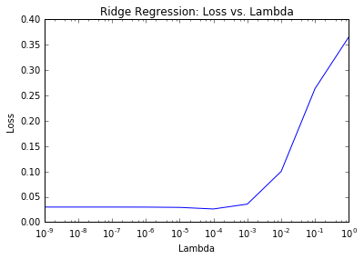

```python
plt.plot(Lambda_hist, loss_hist)
plt.xlabel('Lambda')
plt.ylabel('Loss')
plt.xscale('log')
plt.title('Ridge Regression: Loss vs. Lambda')
plt.show()
```

```python
### Choose 1e-4 as lambda, test model coefficients ###
Lambda = 10**-4
w_min, Lambda, loss_hist = ridge_regression(Lambda)

### Coefficient Report under tolerence=0.0 ###

tolerance = 0.0
false_nonzeros = sum((w_true==0) & (abs(w_min)>=tolerance))
false_zeros = sum((w_true!=0) & (abs(w_min)<tolerance))
true_nonzeros = sum((w_true!=0) & (abs(w_min)>=tolerance))
true_zeros = sum((w_true==0) & (abs(w_min)<tolerance))
print "With tolerence of {0}".format(tolerance)
print "True Value Zero estimated as Nonzero: {0}".format(false_nonzeros)
print "True Value Nonzero estimated as Zero: {0}".format(false_zeros)
print "True Value Zero estimated as Zero: {0}".format(true_zeros)
print "True Value Nonzero estimated as Nonzero: {0}".format(true_nonzeros)

### Coefficient Report under tolerence=0.05 ###

tolerance = 0.05
false_nonzeros = sum((w_true==0) & (abs(w_min)>=tolerance))
false_zeros = sum((w_true!=0) & (abs(w_min)<tolerance))
true_nonzeros = sum((w_true!=0) & (abs(w_min)>=tolerance))
true_zeros = sum((w_true==0) & (abs(w_min)<tolerance))
print "With tolerence of {0}".format(tolerance)
print "True Value Zero estimated as Nonzero: {0}".format(false_nonzeros)
print "True Value Nonzero estimated as Zero: {0}".format(false_zeros)
print "True Value Zero estimated as Zero: {0}".format(true_zeros)
print "True Value Nonzero estimated as Nonzero: {0}".format(true_nonzeros)
```

```
With tolerence of 0.0
True Value Zero estimated as Nonzero: 65
True Value Nonzero estimated as Zero: 0
True Value Zero estimated as Zero: 0
True Value Nonzero estimated as Nonzero: 10
With tolerence of 0.05
True Value Zero estimated as Nonzero: 41
True Value Nonzero estimated as Zero: 0
True Value Zero estimated as Zero: 24
True Value Nonzero estimated as Nonzero: 10
```

## 2. Coordinate Descent for Lasso (a.k.a. The Shooting Algo)

### 2.1 Experiment with the Shooting Algorithm

(1) Write a function that computes the Lasso solution for a given $\lambda$

```python
def soft(a, delta):
    return np.sign(a)*max( abs(a) - delta, 0)

def lasso_shooting(X, y, Lambda=10, tolerance=1e-4):
    (N, D) = X.shape
    maxIt = 1000
    ### Shooting Algo ###
    it = 1
    converged = False
    ### Initialize w ###
    w = np.dot(np.dot(np.linalg.inv(np.dot(X.T, X) + np.identity(D)), X.T), y)
    while (not converged) & (it<maxIt):
        w_old = w.copy()
        for j in range(D):
            aj=cj=0
            for i in range(1,N):
                aj=aj+2*X[i,j]**2
                cj=cj+2*X[i,j]*(y[i]-np.dot(w,X[i,:])+ w[j]*X[i,j])

            w[j] = soft(cj/aj,Lambda/aj)
        it = it + 1
        converged = (sum(abs(w-w_old)) < tolerance)
    #print "Converged:",converged,"Iterations:",it
    return w, converged

### sanity test ###
%timeit lasso_shooting(X_train, y_train, 10)
```

[output not shown]

```python
def timeme(func,iterations=1,*args,**kwargs):
    """
    Timer wrapper.  Runs a given function, with arguments,
    100 times and displays the average time per run.
    """
    def wrapper(func, *args, **kwargs):
        def wrapped():
            return func(*args, **kwargs)
        return wrapped
    wrapped = wrapper(func,*args,**kwargs)
    run_time = float(timeit.timeit(wrapped, number=iterations))/iterations
    print "Avg time to run %s after %i trials: %i seconds per trial" %(func,iterations,run_time)
```

```python
def lambda_search():
    t=0
    Lambdas=[]
    loss_hist=[]
    loss_min = lambda_min=w_opt=np.nan
    print "Start Searching"
    Lambda_max = np.linalg.norm(np.dot(X.T,y),np.inf)
    log_lambda_max = np.log10(Lambda_max)
    for i in np.linspace(-2, log_lambda_max, 15):
        Lambda = 10**i
        print "Lambda",Lambda
        w, converged = lasso_shooting(X_train, y_train, Lambda)
        Lambdas.append(Lambda)
        loss = compute_loss(X_validation, y_validation, w)
        loss_hist.append(loss)
        if t==0:
            loss_min = loss
            lambda_min = Lambda
            w_min = w.copy()
        elif converged:
            if loss<=loss_min:
                loss_min = loss
                lambda_min = Lambda
                w_min = w.copy()
        t=t+1
    best_lost = lasso_shooting(X_test, y_test, lambda_min)
    print "Best Lambda:",lambda_min
    print "Square Loss on Test Data:", loss_min

    return w_opt,Lambdas,loss_hist


timeme(lambda_search,3)
```

```
Start Searching
Lambda 0.01
Converged: False Iterations: 1000
Lambda 0.018977868643
Converged: False Iterations: 1000
Lambda 0.0360159498232
Converged: False Iterations: 1000
Lambda 0.06835059648
Converged: False Iterations: 1000
Lambda 0.129714864167
Converged: False Iterations: 1000
Lambda 0.246171165321
Converged: True Iterations: 927
Lambda 0.467180403917
Converged: True Iterations: 458
Lambda 0.886608833814
Converged: True Iterations: 254
Lambda 1.68259459859
Converged: True Iterations: 186
Lambda 3.19320592715
Converged: True Iterations: 169
Lambda 6.06002426356
Converged: True Iterations: 142
Lambda 11.5006344447
Converged: True Iterations: 54
Lambda 21.8257529804
Converged: True Iterations: 47
Lambda 41.4206273097
Converged: True Iterations: 17
Lambda 78.6075224196
Converged: True Iterations: 7
Converged: True Iterations: 775
Best Lambda: 0.246171165321
Square Loss on Test Data: 0.008095764033
Start Searching
Lambda 0.01
Converged: False Iterations: 1000
Lambda 0.018977868643
Converged: False Iterations: 1000
Lambda 0.0360159498232
```

[output cut: 48 more lines]

```
Converged: True Iterations: 169
Lambda 6.06002426356
Converged: True Iterations: 142
Lambda 11.5006344447
Converged: True Iterations: 54
Lambda 21.8257529804
Converged: True Iterations: 47
Lambda 41.4206273097
Converged: True Iterations: 17
Lambda 78.6075224196
Converged: True Iterations: 7
Converged: True Iterations: 775
Best Lambda: 0.246171165321
Square Loss on Test Data: 0.008095764033
Avg time to run <function lambda_search at 0x115e98758> after 3 trials: 114 seconds per trial
```

```python
w_opt,Lambdas,loss_hist_lasso = lambda_search()
```

```
Start Searching
Lambda 0.01
Converged: False Iterations: 1000
Lambda 0.018977868643
Converged: False Iterations: 1000
Lambda 0.0360159498232
Converged: False Iterations: 1000
Lambda 0.06835059648
Converged: False Iterations: 1000
Lambda 0.129714864167
Converged: False Iterations: 1000
Lambda 0.246171165321
Converged: True Iterations: 927
Lambda 0.467180403917
Converged: True Iterations: 458
Lambda 0.886608833814
Converged: True Iterations: 254
Lambda 1.68259459859
Converged: True Iterations: 186
Lambda 3.19320592715
Converged: True Iterations: 169
Lambda 6.06002426356
Converged: True Iterations: 142
Lambda 11.5006344447
Converged: True Iterations: 54
Lambda 21.8257529804
Converged: True Iterations: 47
Lambda 41.4206273097
Converged: True Iterations: 17
Lambda 78.6075224196
Converged: True Iterations: 7
Converged: True Iterations: 775
Best Lambda: 0.246171165321
Square Loss on Test Data: 0.008095764033
```

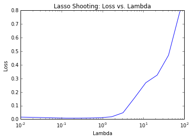

```python
plt.plot(Lambdas,loss_hist_lasso)
plt.xlabel('Lambda')
plt.ylabel('Loss')
plt.xscale('log')
plt.title('Lasso Shooting: Loss vs. Lambda')
plt.show()
```

(2) Analyze the sparsity of your solution, reporting how many components with true value zero have been estimated to be non-zero, and vice-versa.

> There are 3 cases where true value zero were estimated as nonzero. Vice versa never happens

```python
### Choose 0.246171165321 as lambda, test model coefficients ###
Lambda = 0.246171165321
w_opt, _ = lasso_shooting(X_train, y_train, Lambda)

### Coefficient Report under tolerence=0.05 ###
tolerance = 0.05
false_nonzeros = sum((w_true==0) & (abs(w_opt)>=tolerance))
false_zeros = sum((w_true!=0) & (abs(w_opt)<tolerance))
true_nonzeros = sum((w_true!=0) & (abs(w_opt)>=tolerance))
true_zeros = sum((w_true==0) & (abs(w_opt)<tolerance))
print "With tolerence of {0}".format(tolerance)
print "True Value Zero estimated as Nonzero: {0}".format(false_nonzeros)
print "True Value Nonzero estimated as Zero: {0}".format(false_zeros)
print "True Value Zero estimated as Zero: {0}".format(true_zeros)
print "True Value Nonzero estimated as Nonzero: {0}".format(true_nonzeros)
```

```
Converged: True Iterations: 927
With tolerence of 0.05
True Value Zero estimated as Nonzero: 3
True Value Nonzero estimated as Zero: 0
True Value Zero estimated as Zero: 62
True Value Nonzero estimated as Nonzero: 10
```

(3) Implement the homotopy method described above. Compare the runtime for computing the full regularization path (for the same set of $\lambda$’s you tried in the first question above) using the homotopy method compared to the basic shooting algorithm.

```python
def soft(a, delta):
    return np.sign(a)*max( abs(a) - delta, 0)

def homotopy_lasso_shooting(X, y, Lambda=1, tolerance=1e-4, w='undefined'):
    (N, D) = X.shape
    maxIt = 1000
    ### Shooting Algo ###
    it = 1
    converged = False
    ### Initialize w ###
    if w=='undefined':
        w=np.zeros(D)
    while (not converged) & (it<maxIt):
        w_old = w.copy()
        for j in range(D):
            aj=cj=0
            for i in range(1,N):
                aj=aj+2*X[i,j]**2
                cj=cj+2*X[i,j]*(y[i]-np.dot(w,X[i,:])+ w[j]*X[i,j])

            w[j] = soft(cj/aj,Lambda/aj)
        it = it + 1
        converged = (sum(abs(w-w_old)) < tolerance)
    print "Converged:",converged,"Iterations:",it
    return w, converged
#homotopy_lasso_shooting(X_train, y_train, 1)
```

```python
def homotopy_lambda_search():
    t=0
    Lambdas=[]
    loss_hist=[]
    loss_min = lambda_min=w_opt=np.nan
    (N, D) = X.shape
    Lambda_max = np.linalg.norm(np.dot(X.T,y),np.inf)
    log_lambda_max = np.log10(Lambda_max)
    print "Start Searching"
    w_old = w = np.zeros(D)
    for i in np.linspace(log_lambda_max, -2, 15):
        Lambda = 10**i
        print "Lambda = {0}. Warm Starting.....".format(Lambda)

        w_old = w
        w, converged = homotopy_lasso_shooting(X_train, y_train, Lambda=Lambda, w=w_old)

        Lambdas.append(Lambda)
        loss = compute_loss(X_validation, y_validation, w)
        loss_hist.append(loss)
        if t==0:
            loss_min = loss
            lambda_min = Lambda
            w_min = w.copy()
        elif converged:
            if loss<=loss_min:
                loss_min = loss
                lambda_min = Lambda
                w_min = w.copy()
        t=t+1
    best_lost = homotopy_lasso_shooting(X_test, y_test, lambda_min)
    print "Best Lambda:",lambda_min
    print "Square Loss on Test Data:", loss_min

    return w_opt,Lambdas,loss_hist

timeme(homotopy_lambda_search)
#%timeit w_lasso,lambdas_lasso,loss_hist_lasso = homotopy_lambda_search()
```

```
Start Searching
Lambda = 78.6075224196. Warm Starting.....
Converged: True Iterations: 3
Lambda = 41.4206273097. Warm Starting.....
Converged: True Iterations: 22
Lambda = 21.8257529804. Warm Starting.....
Converged: True Iterations: 44
Lambda = 11.5006344447. Warm Starting.....
Converged: True Iterations: 44
Lambda = 6.06002426356. Warm Starting.....
Converged: True Iterations: 140
Lambda = 3.19320592715. Warm Starting.....
Converged: True Iterations: 171
Lambda = 1.68259459859. Warm Starting.....
Converged: True Iterations: 165
Lambda = 0.886608833814. Warm Starting.....
Converged: True Iterations: 192
Lambda = 0.467180403917. Warm Starting.....
Converged: True Iterations: 302
Lambda = 0.246171165321. Warm Starting.....
Converged: True Iterations: 647
Lambda = 0.129714864167. Warm Starting.....
Converged: True Iterations: 875
Lambda = 0.06835059648. Warm Starting.....
Converged: False Iterations: 1000
Lambda = 0.0360159498232. Warm Starting.....
Converged: True Iterations: 886
Lambda = 0.018977868643. Warm Starting.....
Converged: False Iterations: 1000
Lambda = 0.01. Warm Starting.....
Converged: False Iterations: 1000
Converged: False Iterations: 1000
Best Lambda: 0.129714864167
Square Loss on Test Data: 0.00802342043097
Avg time to run <function homotopy_lambda_search at 0x115e1b398> after 1 trials: 105 seconds per trial
```

(4) Implement the matrix expressions and measure the speedup to compute the regularization path.

```python
def soft(a, delta):
    return np.sign(a)*max( abs(a) - delta, 0)

def vect_homotopy_lasso_shooting(X, y, Lambda=1, tolerance=1e-4, w='undefined'):
    (N, D) = X.shape
    maxIt = 1000
    ### Shooting Algo ###
    it = 1
    converged = False
    ### Initialize w ###
    if w=='undefined':
        w=np.zeros(D)
    while (not converged) & (it<maxIt):
        w_old = w.copy()
        for j in range(D):
            aj = 2*np.dot(X[:,j].T,X[:,j])
            cj = 2*(X[:,j].dot(y) - (w.T.dot(X.T)).dot(X[:,j]) + w[j]*(X[:,j].T.dot(X[:,j])))
            w[j] = soft(cj/aj,Lambda/aj)
        it = it + 1
        converged = (sum(abs(w-w_old)) < tolerance)
    print "Converged:",converged,"Iterations:",it
    return w, converged
#homotopy_lasso_shooting(X_train, y_train, 1)
```

```python
def vect_homotopy_lambda_search():
    t=0
    Lambdas=[]
    loss_hist=[]
    loss_min = lambda_min=w_opt=np.nan
    (N, D) = X.shape
    Lambda_max = np.linalg.norm(np.dot(X.T,y),np.inf)
    log_lambda_max = np.log10(Lambda_max)
    print "Start Searching"
    w_old = w = np.zeros(D)
    for i in np.linspace(log_lambda_max, -2, 15):
        Lambda = 10**i
        print "Lambda = {0}. Warm Starting.....".format(Lambda)

        w_old = w
        w, converged = vect_homotopy_lasso_shooting(X_train, y_train, Lambda=Lambda, w=w_old)

        Lambdas.append(Lambda)
        loss = compute_loss(X_validation, y_validation, w)
        loss_hist.append(loss)
        if t==0:
            loss_min = loss
            lambda_min = Lambda
            w_min = w.copy()
        elif converged:
            if loss<=loss_min:
                loss_min = loss
                lambda_min = Lambda
                w_min = w.copy()
        t=t+1
    best_lost = vect_homotopy_lasso_shooting(X_test, y_test, lambda_min)
    print "Best Lambda:",lambda_min
    print "Square Loss on Test Data:", loss_min

    return w_opt,Lambdas,loss_hist

timeme(vect_homotopy_lambda_search)
#%timeit w_lasso,lambdas_lasso,loss_hist_lasso = homotopy_lambda_search()
```

```
Start Searching
Lambda = 78.6075224196. Warm Starting.....
Converged: True Iterations: 3
Lambda = 41.4206273097. Warm Starting.....
Converged: True Iterations: 22
Lambda = 21.8257529804. Warm Starting.....
Converged: True Iterations: 44
Lambda = 11.5006344447. Warm Starting.....
Converged: True Iterations: 44
Lambda = 6.06002426356. Warm Starting.....
Converged: True Iterations: 146
Lambda = 3.19320592715. Warm Starting.....
Converged: True Iterations: 175
Lambda = 1.68259459859. Warm Starting.....
Converged: True Iterations: 168
Lambda = 0.886608833814. Warm Starting.....
Converged: True Iterations: 196
Lambda = 0.467180403917. Warm Starting.....
Converged: True Iterations: 313
Lambda = 0.246171165321. Warm Starting.....
Converged: True Iterations: 666
Lambda = 0.129714864167. Warm Starting.....
Converged: True Iterations: 884
Lambda = 0.06835059648. Warm Starting.....
Converged: False Iterations: 1000
Lambda = 0.0360159498232. Warm Starting.....
Converged: True Iterations: 803
Lambda = 0.018977868643. Warm Starting.....
Converged: True Iterations: 631
Lambda = 0.01. Warm Starting.....
Converged: False Iterations: 1000
Converged: False Iterations: 1000
Best Lambda: 0.129714864167
Square Loss on Test Data: 0.00787268083111
Avg time to run <function vect_homotopy_lambda_search at 0x115ede230> after 1 trials: 5 seconds per trial
```

### 2.2 Deriving the Coordinate Minimizer for lasso

(1) First let's get a trival case out of the way. If $x_{ij}=0$ for $i=1,...,n$, what is the coordinate minimizer $w_j$?

> **ANSWER**

> $w_j=0$

(2) Write the derivative of $f(w_j)$.

> **ANSWER**

> $\begin{array}{cc} \partial_{w_j}f(w_j) & = & (a_j w_j -c_j)+\lambda \partial_{w_j}\|w_j\|_1 \\ &=& a_j w_j-c_j+sign(w_j)\lambda \end{array}$

(3) If $w_j>0$ and minimizes $f$, then show that $w_j=-\frac{1}{a_j}(\lambda-c_j)$. Similarly, if $w_j<0$ and minimizes $f$, show that $w_j=\frac{1}{a_j}(\lambda+c_j)$. Give conditions on $c_j$ that imply the minimizer $w_j>0$ and $w_j<0$, respectively.

> **ANSWER**

> The magnitude of $c_j$ is an indication of relevance feature j is for predicting y.

> If $c_j>\lambda$, then feature $j$ is strongly possitively correlated with the residual, so $w_j>0$.

> If $c_j<-\lambda$, then feature $j$ is strongly negatively correlated with the residual, so $w_j<0$.

(4) Derive expressions for the two one-sided derivative at $f(0)$, and show that $c_j \in [-\lambda, \lambda]$ implies that $w_j=0$ is a minimizer.

> **ANSWER**

> $$a = \lim_{w\to0}\frac{\|w\|-\|0\|}{w}=1$$$$b = \lim_{w\to0}\frac{\|-w\|)-\|0\|)}{w}=-1$$

> The derivative for the $f(w_j)$ is

> $$[-c_j+\lambda b, -c_j +\lambda a]=[-c_j-\lambda,-c_j+\lambda]$$

> $\therefore$ 0 is the minimizer.

(5) Conclude the minimizer.

> If $c_j>\lambda$, then feature $j$ is strongly possitively correlated with the residual, so $w_j>0$ and $w_j=-\frac{1}{a_j}(\lambda-c_j)$.

> if $c_j\in[-\lambda,\lambda]$, $w_j=0$ is a minimizer.

> If $c_j<-\lambda$, then feature $j$ is strongly negatively correlated with the residual, so $w_j<0$ and $w_j=\frac{1}{a_j}(\lambda+c_j)$.

## 3 Lasso Properties

### 3.1 Deriving $\lambda_{max}$

(1) Compute $L_{'}(0;v)$.

> **ANSWER**

> $\begin{array}{cc} L^{'}(0;v)&=&\lim\limits_{h\to 0}\frac{1}{h}[\|Xhv-y\|_2^2+\lambda\|hv\|_1-\|y\|^2-\lambda\|0\|]\\ &=&-2(Xv)^T y+\lambda\|v\| \end{array}$

(2) Since the Lasso objective is convex, for $w^*$ to be a minimizer of $L(w)$ we must have that the directional derivative $L^{'}(w^*;v)\geq 0$ for all v. Starting form the condition $L^{'}(0;v)\geq 0$, rearrange terms to get a lower bounds on $\lambda$.

> **ANSWER**

> $\begin{array}{cc} 0&\leq&L^{'}(0;v)\\ &\leq&-2vX^T y+\lambda\|v\|\\ \lambda&\geq&\frac{2v X^T y}{\|v\|_1}\quad for\quad every\quad v\\ \end{array}$

> $\lambda$'s lower bound is $\frac{2v X^T y}{\|v\|_1}$

(3) Since our lower bounds on $\lambda$ for all $v$, we want to compute the maximum lower bound. Compute the maximum lower bound of $\lambda$ by maximizing the expression over $v$. Show that this expression is equivalent to $\lambda_{max}=2\|X^Ty\|_\infty$.

> **ANSWER**

> $\begin{array}{lll} L'(w,v) &=& \lim\limits_{h\to 0}\frac{L(w+hv)-L(w)}{h}\\ &=&\lim\limits_{h\to 0}\frac{(X(w+hv)-y)^T(X(w+hv)-y)+\lambda(\|w+hv\|_1-\|w\|_1)}{h}\\ &=&2X^T(Xw-y)v+\lambda(\sum\limits_{j,w_j\neq0}sign(w_j)v_j+\sum\limits_{j,w_j=0}|v_j|) \end{array}$

> Lower bounds for all v and w should be,

> $\lambda_{max}\geq\frac{2X^T(y-Xw)v}{\sum\limits_{j,w_j\neq0}sign(w_j)v_j+\sum\limits_{j,w_j=0}|v_j|}=2\|X^Ty\|_\infty$

(4) Show that for $L(w)=\|Xw+b-y\|^2_2+\lambda\|w\|_1$,$\lambda_{max}=2\|X^T(y-\bar y)\|_\infty$ where $\bar y$ is the mean of valus in the vector $y$.

> **ANSWER**

> $L(w) = \sum\limits_{i=1}^{n}(w^Tx_i+b-y_i)+\lambda\|w\|_1$

> $\begin{array}{ll} 0&\leq&L^{'}(0;v)\\ &\leq&-2vX^T (y-b)+\lambda\|v\|\\ \end{array}$

> Therefore,

> $\begin{array}{ll} \lambda &\geq&2\frac{v}{\|v\|_1} X^T (y-b)\\ &=&2\|X^T(y-b)\|_\infty\\ &=&2\|X^T(y-\bar y+\bar y-b)\|\\ &\geq&2\|X^T(y-\bar y)\|_\infty \end{array}$

> Hence,

> $\lambda_{max} = 2\|X^T(y-\bar y)\|_\infty$

### 3.2 Feature Correlation

(1) Derive the relation between $\hat \theta_i$ and $\hat \theta_j$, the $i^{th}$ and the $j^{th}$ components of the optimal weight vector obtained by solving the Lasso optimization problem.

> **ANSWER**

> Assume $\hat{\theta}_i=a$ and $\hat{\theta}_j=b$

> The lasso objective function, below, must minimize both loss and regularization.

> $$\sum\limits_{k=1}^n (h(x_k) - y_k)^2 + \lambda\|w\|_1$$

> First consider the loss, $\sum\limits_{k=1}^n (h(x_k) - y_k)^2$, where $h(x_k)=\mathbf w^Tx_k$

> The loss due to $x_i$, $x_j$ is $\sum\limits_{k=1}^n (\hat{\theta}_iX_{ik} + \hat{\theta}_jX_{jk} - y_k)$

> Since $X_i=X_j$, this simplifies to $\sum\limits_{k=1}^n ((\hat{\theta}_i + \hat{\theta}_j)X_{ik} - y_k)$

> Thus the optimal values $a$ and $b$ must sum to another value $c$ that minimizes this expression $\sum\limits_{k=1}^n (cX_{ik} - y_k)$

> Next we minimize the lasso regularization component, $\lambda||w||_1 = \lambda\sum\limits_{l=1}^d|w_l|$

> The regularization penalty due to $x_i$, $x_j$ is $|a| + |b|$. If $a$ and $b$ are of opposite sign, and both are nonzero, then $|a| + |b|$ > $|c| + |0|$, and the regularization penalty is not minimized. Therefore $a$ and $b$ must be of the same sign and are constrained by optimal value $c$ such that $a+b=c$

(2) Derive the relation between $\hat{\theta}_i$ and $\hat{\theta}_j$, the $i^{th}$ and $j^{th}$ components of the optimal weight vector obtained by solving the ridge regression optimization problem.

> The ridge regression objective function, below, must minimize both loss and regularization.

> $\sum\limits_{k=1}^n (h(x_k) - y_k)^2 + \lambda\|w\|_2^2$

> The loss component is the same as with lasso, so we must minimize the regularization penalty subject to the same constraint as in lasso, which is that $a + b = c$

> The regularization penalty due to $x_i$, $x_j$ is $a^2 + b^2$. Next I will show that $a^2 + b^2 \ge (\frac{c}{2})^2 + (\frac{c}{2})^2$, and therefore $a$ and $b$ must be equal to $\frac{c}{2}=\frac{a+b}{2}$ under these conditions.

> Claim: $a^2 + b^2 \ge 2(\frac{c}{2})^2$

> Proof:

> $\begin{array}{lll} a^2 + b^2 &=& a^2 + (c-a)^2\\ &=& a^2 + c^2 - 2ac + a^2\\ &=& 2a^2 + c^2 - 2ac\\ &=& \frac{1}{2}(4a^2 - 4ac + 2c^2)\\ &=& \frac{1}{2}(2a-c)^2 + \frac{c^2}{2}\\ &=& \frac{1}{2}(2a-c)^2 + 2(\frac{c}{2})^2\\ &=& \frac{1}{2}(2a-c)^2 \ge 0 \end{array}$

> therefore $\frac{1}{2}(2a-c)^2 + 2(\frac{c}{2})^2 \ge 2(\frac{c}{2})^2$

> Thus $a$ and $b$ must be equal.

## 4 The Ellipsoids in the $\ell_1/\ell_2$ regularization picture

(1) Let $\hat w = (X^T X)^{-1}X^Ty$. Show that $\hat w$ has empirical risk given by $$\hat R_n(\hat w)=\frac{1}{n}(-y^TX\hat w+y^Ty)$$

> **ANSWER**

> $\begin{array}{lll} \hat R_n(\hat w) &=& \frac{1}{n}(Xw-y)^T(Xw-y) \\ &=& \frac{1}{n}(w^TX^TXw-2w^TX^Ty+y^Ty)\\ &=& \frac{1}{n}[w^TX^T(Xw-2y)+y^Ty]\\ &=& \frac{1}{n}[w^TX^T(-2y+X(X^T X)^{-1}X^Ty)+y^Ty]\\ &=& \frac{1}{n}[-w^TX^Ty+y^Ty]\\ &=& \frac{1}{n}\{-[(X^T X)^{-1}X^Ty]^TX^Ty+y^Ty\}\\ &=& \frac{1}{n}[-y^TX[(X^TX)^{-1}X^Ty]+y^Ty]\\ &=& \frac{1}{n}[-y^TX\hat w+y^Ty] \end{array}$

(2) Show that for any $w$ we have $$\hat R_n(w)=\frac{1}{n}(w-\hat w)^TX^TX(w-\hat w)+\hat R_n(\hat w)$$

> **ANSWER**

> $\begin{array}{lll} \hat R_n(w) &=& \frac{1}{n}(Xw-y)^T(Xw-y)\\ &=& \frac{1}{n}[w^T(X^TX)w-2(X^Ty)^Tw+y^Ty]\\ &=& \frac{1}{n}\{[w-(X^TX)^{-1}X^Ty]^T(X^TX)[w-(X^TX)^{-1}X^Ty]-(X^Ty)^T(X^TX)^{-1}X^Ty+y^Ty\}\\ &=& \frac{1}{n}[(w-\hat w)^T(X^TX)(w-\hat w)-y^TX\hat w+y^Ty]\\ &=& \frac{1}{n}(w-\hat w)^T(X^TX)(w-\hat w)+\hat R_n(\hat w) \end{array}$

(3) Using the expression in (2), give a very short proof that $\hat w=(X^TX)^{-1}X^Ty$ is the empirical risk minimizer. That is: $$\hat w=\underset{w}{\mathrm{argmin}}\hat R_n(w)$$

> **ANSWER**

> $X^TX$ is positive semidefinite

> $\therefore \forall (w-\hat w)\in \mathbf R^d, $

> $\Phi(w)=(w-\hat w)^TX^TX(w-\hat w)\geq 0$

> Hence $\hat w$ is the minimizer of $\Phi(w)$

> $\hat R_n(w)=\frac{1}{n}\Phi(w)+\hat R_n(\hat w)\geq \hat R_n(\hat w)$

> Therefore, $\hat w$ is also the minimizer fo the empirical risk $\hat R_n(w)$

(4) Give an expression for the set of $w$ for which the empirical risk exceeds the minimum empirical risk $\hat R_n(\hat w)$ by an amount $c>0$. This set is an ellipse - what is its center?

> **ANSWER**

> $\{w\quad |\quad (w-\hat w)^TX^TX(w-\hat w)=c,c>0\}$ is an ellipsoid centered at $\hat w$

## 5 Projected SGD via Variable Splitting

(1) Implement projected SGD to solve the above optimization problem for the same value $\lambda$'s as used with the shooting algorithm.

```python
def compute_sgd_loss(X, y, w_p, w_n, Lambda):
    m = y.size
    hX = (w_p - w_n).dot(X.T)
    #loss = ((np.square(hX - y))/(m)).sum() + Lambda*((w_p+w_n).sum())
    loss = ((np.square(hX - y))/(2*m)).sum()
    return loss
```

```python
def compute_sgd_gradient(X, y, i, w_p, w_n, Lambda, component):
    if component is 'p':
        grad = (X[i].dot(w_p-w_n)-y[i])*(X[i]) + Lambda
    elif component is 'n':
        grad = -(X[i].dot(w_p-w_n)-y[i])*(X[i]) + Lambda
    return grad
```

```python
def projected_sgd(X,y,validation_X, validation_y, Lambda=0.3, alpha=0.1, beta=0.1, num_iter=5000):
    m,d = X.shape
    w = np.random.rand(d,1) #initialize weight
    w_p = np.zeros(d)
    w_n = np.zeros(d)
    for i in range(d):
        if w[i] > 0:
            w_p[i] = w[i]
        else:
            w_n[i] = w[i]

    opt_loss=1000
    opt_w = w
    step=0
    epoch=0

    order = range(m)

    for j in range(num_iter + 1):
        np.random.shuffle(order)

        for k in range(m):
            loss = compute_sgd_loss(validation_X, validation_y, w_p, w_n, Lambda)
            grad_p = compute_sgd_gradient(X, y, order[k], w_p, w_n, Lambda, component='p')
            grad_n = compute_sgd_gradient(X, y, order[k], w_p, w_n, Lambda, component='n')

            if loss < opt_loss:
                opt_loss = loss
                opt_w = w_p - w_n
                step = j*m+k+1
                epoch= j+1

            if alpha is "1/t":
                alpha=beta*(1./(j*m+k+1))
            elif alpha is "1/sqrt(t)":
                alpha=beta*(1./np.sqrt(j*m+k+1))
            else:
                alpha=alpha

            w_p = w_p - alpha*grad_p
            w_n = w_n - alpha*grad_n

            for i in range(d):
                if w_p[i] < 0:
                    w_p[i] = 0
                elif w_n[i] < 0:
                    w_n[i] = 0
    return opt_loss, opt_w, w_p, w_n
```

```python
loss = []
w = []
loss1=[]
w1=[]
Lambda_max = np.linalg.norm(np.dot(X_train.T,y_train),np.inf)
log_lambda_max = np.log10(Lambda_max)
print "Start Searching"

for i in np.linspace( -2,log_lambda_max, 15):
    Lambda = 10**i;
    opt_loss, opt_w, w_p, w_n = projected_sgd(X_train,y_train,X_validation, y_validation, Lambda=Lambda, alpha=0.005, num_iter=5000)
    opt_w1, converged = lasso_shooting(X_train, y_train, Lambda)
    opt_loss1 = compute_loss(X_validation, y_validation, opt_w1)
    loss.append(opt_loss)
    w.append(opt_w)
    w1.append(opt_w1)
    loss1.append(opt_loss1)
```

```
Start Searching
Converged: False Iterations: 1000
Converged: False Iterations: 1000
Converged: False Iterations: 1000
Converged: False Iterations: 1000
Converged: False Iterations: 1000
Converged: False Iterations: 1000
Converged: True Iterations: 587
Converged: True Iterations: 310
Converged: True Iterations: 213
Converged: True Iterations: 178
Converged: True Iterations: 157
Converged: True Iterations: 129
Converged: True Iterations: 52
Converged: True Iterations: 47
Converged: True Iterations: 22
```

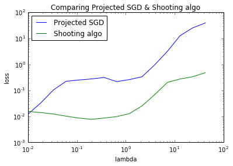

```python
plt.plot([10**i for i in np.linspace( -2,log_lambda_max, 15)], loss, label="Projected SGD")
plt.plot([10**i for i in np.linspace( -2,log_lambda_max, 15)], loss1, label="Shooting algo")
plt.gca().set_xscale("log")
plt.gca().set_yscale("log")
plt.legend(loc="best")
plt.xlabel('lambda')
plt.ylabel('loss')
plt.title('Comparing Projected SGD & Shooting algo')
```

```python
#Analyze the sparsity of the projected SGD solution
loss_array = np.array(loss)
indx = np.where(loss_array ==loss_array.min())[0][0]
w_opt = w[indx]
### Coefficient Report under tolerence=0.05 ###
tolerance = 0.05
false_nonzeros = sum((w_true==0) & (abs(w_opt)>=tolerance))
false_zeros = sum((w_true!=0) & (abs(w_opt)<tolerance))
true_nonzeros = sum((w_true!=0) & (abs(w_opt)>=tolerance))
true_zeros = sum((w_true==0) & (abs(w_opt)<tolerance))
print "With tolerence of {0}".format(tolerance)
print "True Value Zero estimated as Nonzero: {0}".format(false_nonzeros)
print "True Value Nonzero estimated as Zero: {0}".format(false_zeros)
print "True Value Zero estimated as Zero: {0}".format(true_zeros)
print "True Value Nonzero estimated as Nonzero: {0}".format(true_nonzeros)
```

```
With tolerence of 0.05
True Value Zero estimated as Nonzero: 0
True Value Nonzero estimated as Zero: 0
True Value Zero estimated as Zero: 65
True Value Nonzero estimated as Nonzero: 10
```

```python
#Analyze the sparsity of the projected SGD solution
loss_array = np.array(loss1)
indx = np.where(loss_array ==loss_array.min())[0][0]
w_opt = w1[indx]
### Coefficient Report under tolerence=0.05 ###
tolerance = 0.05
false_nonzeros = sum((w_true==0) & (abs(w_opt)>=tolerance))
false_zeros = sum((w_true!=0) & (abs(w_opt)<tolerance))
true_nonzeros = sum((w_true!=0) & (abs(w_opt)>=tolerance))
true_zeros = sum((w_true==0) & (abs(w_opt)<tolerance))
print "With tolerence of {0}".format(tolerance)
print "True Value Zero estimated as Nonzero: {0}".format(false_nonzeros)
print "True Value Nonzero estimated as Zero: {0}".format(false_zeros)
print "True Value Zero estimated as Zero: {0}".format(true_zeros)
print "True Value Nonzero estimated as Nonzero: {0}".format(true_nonzeros)
```

```
With tolerence of 0.05
True Value Zero estimated as Nonzero: 5
True Value Nonzero estimated as Zero: 0
True Value Zero estimated as Zero: 60
True Value Nonzero estimated as Nonzero: 10
```

Compare Projected SGD with Lasso Shooting, the Projected SGD solution has more sparsity.